# Migrating COM API calls to Python

### What are the COM APIs

The COM APIs are older APIs that were initially delivered with 3000 Xtra Terminals and then Eikon. They provided access to a broad set of content and capabilities in Eikon.

The COM API covers a large range of functionalities, as shown in [this article](https://developers.refinitiv.com/en/article-catalog/article/event-driven-financial-calculation-with-eikon-excel-visual-basic). Below we will show you how to migrate the following COM Component and API calls/functions:

- AdfinXRtLib (rtx.dll)
  - AdxRtSourceList
  - AdxRtList (including 'RtGet Real Time')
  - AdxRtChain
  - AdxRtHistory (both inter- and intra-day) - Only available in Excel
  - Streaming News
- dex2.dll
  - Rdata List
  - DEX2 (including Symbology Conversion, Time Series, Fundamental and Reference data)
- RHistoryAPI.dll
  - RHistory
- RSearch.dll
  - RSearch
- RtContribute.dll
  - RtContribute

----The APIs below do not currently have replacements in Workspace---------------

- Adxfo.dll
  - AdfinX Analytics 2.0 Module
- Adxfoo.dll
  - AdfinX Analytics 3.0 Module

### Reasons you might need or want to migrate away from COM APIs:

### Need to operate in 64-bit environment

The COM APIs were designed to be used in 32-bit environments. Many teams are stil migrating to 64-bit environments where these will not work correctly and are not supported environments.

### You want access to new datasets and improved capabilties offered on Refinitiv Data Platform

The COM APIs are feature-complete and no new development work is being done on them. This means that new datasets and capabilities will not be available to users of these APIs.

### You want to upgrade from Eikon to Workspace

The COM APIs will not be available in Workspace - so to take advantage of the best desktop experience you would need to migrate to our more modern web-based APIs - which are much better and work with modern scripting environments such as Python - one of the most popular language ecosystems used in finance.

All the Python code below works in Codebook too! You can try it out as outlined in this [Tutorial Video](https://developers.refinitiv.com/en/video-catalog/from-developer-articles-to-codebook). We will use the Refinitiv Data Library (RD Library). To learn more about the Refinitiv Data Library for Python please join the Refinitiv Developer Community. By [registering](https://developers.refinitiv.com/iam/register) and [logging](https://developers.refinitiv.com/content/devportal/en_us/initCookie.html) into the Refinitiv Developer Community portal you will have free access to a number of learning materials like:

- [Quick Start guides](https://developers.refinitiv.com/en/api-catalog/refinitiv-data-platform/refinitiv-data-library-for-python/quick-start),
- [Tutorials](https://developers.refinitiv.com/en/api-catalog/refinitiv-data-platform/refinitiv-data-library-for-python/learning),
- [Documentation](https://developers.refinitiv.com/en/api-catalog/refinitiv-data-platform/refinitiv-data-library-for-python/docs)

including the ability to ask questions on our Q&A forums and much more.

## Prerequisites

### COM Prerequisites

Documentation on using the COM API in the Microsoft Office suite is available here: [COM APIs for Microsoft Office](https://developers.refinitiv.com/en/api-catalog/eikon/com-apis-for-use-in-microsoft-office/tutorials). Users were also able to use the COM APIs outside of Microsoft Office suite for example in a standalone app: [COM APIs for use in custom applications](https://developers.refinitiv.com/en/api-catalog/eikon/com-apis-for-use-in-custom-applications). A list of the prerequisites in question can be found in the index of this article.

If you are new to [Python](https://www.python.org/), don't hesitate to install it on your machine and try it out yourself as outlined in this 3rd party [tutorial](https://pythonprogramming.net/introduction-learn-python-3-tutorials/). Otherwise, you can simply use Codebook as outlined in this [Tutorial Video](https://developers.refinitiv.com/en/video-catalog/from-developer-articles-to-codebook).

Python works with libraries that one can import to use functionalities that are not natively supported by the base coding package. Some popular distributuions of python include many of the popular packages that one could use for various tasks - [Anaconda](https://www.anaconda.com/) is the most popular such distribution.

The RD Library allows for code portability across the desktop and enterprise platforms - with only small changes in authentication credentials. These credentials are stored in a config file - but if you are just using the desktop you need not concern yourself with this as a desktop session is the default credential setup.

```python
import refinitiv.data as rd # pip install httpx==0.21.3 # !pip install refinitiv.data --upgrade
from refinitiv.data.discovery import Chain
from refinitiv.data.content import search
import pandas as pd
pd.set_option('display.max_columns', None)
import numpy as np
import os
import time
import datetime  # `datetime` allows us to manipulate time as we would data-points.
from IPython.display import display, clear_output  # `IPython` here will allow us to plot grahs and the likes.
```

```python
rd.open_session("desktop.workspace")
```

```
<refinitiv.data.session.Definition object at 0x7fa34230ac18 {name='workspace'}>
```

## AdfinX RealTime AdxRtSourceList

### What does 'AdfinX RealTime AdxRtSourceList' do?

This functionality was used to get the real-time field list for the selected Source Name, such as an instrument (e.g.: VOD.L) (using AdxRtSourceList Class of AdfinXRtLib, the AdfinX Real Time 6.0 Library, rtx.dll). It was best demonstrated in the [Tutorial 1 - Real-time Source List, Fields - AdxRtSourceList](https://developers.refinitiv.com/en/api-catalog/eikon/com-apis-for-use-in-microsoft-office/tutorials#tutorial-1-real-time-source-list-fields-adx-rt-source-list)'s [Excel Workbook](https://developers.refinitiv.com/content/dam/devportal/api-families/eikon/com-apis-for-use-in-microsoft-office/tutorials/adxrtsourcelist.zip):

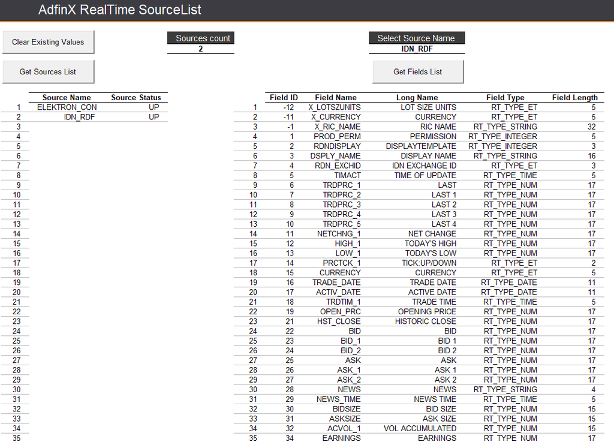

### VBA

The VBA for AdxRtSourceList is very simple, and consists simply in creating an instance of an AdxRtSourceList object using the PLVbaApis function:

> Set myAdxRtSrcLst = CreateAdxRtSourceList()

### New Method

This functionality is replaced with a user interface called the [Data Item Browswer (DIB) that you can find on workspace](https://emea1-apps.platform.refinitiv.com/web/Apps/DataItemBrowser/), and for which there is a [video tutorial](https://developers.refinitiv.com/en/video-catalog/data-item-browser). This will give you a list of all real-time and non-real-time fields available for a particular instrument. For real-time fields the RD library can also provide this programatically - see below:

#### Real-Time Fields Available With The COM API

There are a limited number of fields available on the COM API in 'AdxRtSourceList', you can lookup fields available in the Quote app for any instrument in question:

[figure not shown]

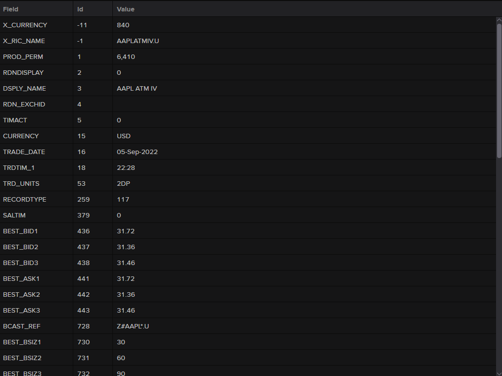

More are available on the DIB and via the code available below in the 'Real-Time Fields Available In Python' section.

Note that available fields for each instrument type difffers on the type.

Note that the CF_ fields are also available to streaming Desktop sessions (not to platform sessions due to differences in data licenses)

#### Real-Time Fields Available In Python

You can get a collection of all the Real-Time fields available via:

```python
RTCurrDf = rd.get_data(universe=['GBP='])
print(list(RTCurrDf.columns))
```

```
['Instrument', 'PROD_PERM', 'RDNDISPLAY', 'DSPLY_NAME', 'TIMACT', 'NETCHNG_1', 'HIGH_1', 'LOW_1', 'CURRENCY', 'ACTIV_DATE', 'OPEN_PRC', 'HST_CLOSE', 'BID', 'BID_1', 'BID_2', 'ASK', 'ASK_1', 'ASK_2', 'ACVOL_1', 'TRD_UNITS', 'PCTCHNG', 'OPEN_BID', 'OPEN_ASK', 'CLOSE_BID', 'CLOSE_ASK', 'NUM_MOVES', 'OF…
```

Note that available fields for each instrument type difffers on the type, e.g.:

```python
ATMIVDf = rd.get_data(universe=['AAPLATMIV.U'])
print(list(ATMIVDf.columns))
```

```
['Instrument', 'PROD_PERM', 'RDNDISPLAY', 'DSPLY_NAME', 'RDN_EXCHID', 'TIMACT', 'CURRENCY', 'TRADE_DATE', 'TRDTIM_1', 'TRD_UNITS', 'RECORDTYPE', 'SALTIM', 'BEST_BID1', 'BEST_BID2', 'BEST_BID3', 'BEST_ASK1', 'BEST_ASK2', 'BEST_ASK3', 'BCAST_REF', 'BEST_BSIZ1', 'BEST_BSIZ2', 'BEST_BSIZ3', 'BEST_ASIZ1'…
```

## AdfinX RealTime AdxRtList

### What does AdxRtList do?

Returns real-time data for multiple (or single) instrument and fields. Data is returned initially as ONIMAGE - which is a snapshot of data for the requested fields, followed by a series of ONUPDATE messages - which are received whenever a data item changes or gets updated. You can also request ONTIME returns which would give an ONIMAGE snapshot at periodic intervals (say every hour for example). All the following functions rely on AdxRtList API calls - RtGet(), RData() and TR() for real-time data. Typically we would need to write callback handlers to deal with the returns from the API.

### RtGet Real-Time

The functionalities shown here are easily recreated using the RD Library:

1. Real Time FX rates snapshot - 'Real-Time ONIMAGE'
2. 'Real Time Update', which updates real time, as soon as an update for the instrument and field is received
3. A periodic ONTIME snapshot

#### Real-Time ONIMAGE

When collecting data ONIMAGE, we are collecting a current snapshot of the data we're after. This could not be simpler in RD in Python!

##### VBA

In VBA, you'd create an instance of an AdxRtList object using the PLVbaApis function CreateAdxRtList.

> Set myRtGet = CreateAdxRtList() ' The code will replicate RtGet(), one instrument, one field.'

> Set myAdxRtList = CreateAdxRtList() ' The code will replicate RData(), multiple items & fields.'

Then create your function `cmdGetRealTimeONIMAGE_Click`:

> ```
>     Private Sub cmdGetRealTimeONIMAGE_Click()
>     Dim strRICs As String  ' Can have one or more items
>     Dim varFIDs As Variant ' Field can be numeric as well as a string, e.g. BID is field 22
>
>     ActiveCell.Select
>
>     If Not myRtGet Is Nothing Then Set myRtGet = Nothing
>     Set myRtGet = CreateAdxRtList()
>
>     With myRtGet
>         .ErrorMode = DialogBox
>         .Source = [Source].Value
>         strRICs = [RIC].Value
>         varFIDs = [FID].Value
>
>         .RegisterItems strRICs, varFIDs
> '       'Different methods shown below.
> '        strRICs = "EUR="
> '        varFIDs = "BID"
> '        .RegisterItems strRICs, varFIDs
> '        .RegisterItems "EUR=,GBP=,JPY=", "BID,ASK"
>
>         .StartUpdates RT_MODE_IMAGE ' 4
>         '.StartUpdates RT_MODE_ONUPDATE ' 3
>         '.StartUpdates RT_MODE_NOT_SET ' 5
>         '.StartUpdates RT_MODE_ONTIME ' 2
>         '.StartUpdates RT_MODE_ONTIME_IF_UPDATED ' 1
>     End With ' For the With myRtGet
> End Sub
> ```

This would allow, in this example, for the 'Get Real Time ONIMAGE' buttons to work. For updates, the below could be used:

> ```
> ' Returns the initial image for the instrument. NOTE - .StartUpdates RT_MODE_IMAGE
> Private Sub myRtGet_OnImage(ByVal DataStatus As AdfinXRtLib.RT_DataStatus)
>     Dim arrRICs As Variant, arrFields As Variant
>     Dim lngRICFidVal As Single
>     Dim a As Integer
>
>     If DataStatus = RT_DS_FULL Then
>         With myRtGet
>             ' Array of the list of instruments - only one in this case.
>             arrRICs = .ListItems(RT_IRV_ALL, RT_ICV_USERTAG)
>             ' Array of the list of Fields for the ath item in the arrRics (base 0)
>             a = 0
>             arrFields = .ListFields(arrRICs(a, 0), RT_FRV_ALL, RT_FCV_VALUE)
>         End With
>
>         ' And a specific value for a specific instrument, specific field.
>         'lngRICFidVal = myRtGet.Value("EUR=", "BID")
>         lngRICFidVal = myRtGet.Value([RIC].Value, [FID].Value)
>         [F7].Value = lngRICFidVal
>     End If
> End Sub
> ```

##### Python

In python, things could not be easier as most of the equivalent code about is abstracted to the library and you just use a one-line function! You can go ahead and try it all out in Codebook:

```python
rd.get_data(
    universe=['GBP=', 'EUR=', 'JPY='],
    fields=['BID', 'ASK'])
```

|  | Instrument | BID | ASK |
| --- | --- | --- | --- |
| 0 | GBP= | 1.2002 | 1.2006 |
| 1 | EUR= | 1.0665 | 1.0666 |
| 2 | JPY= | 135.96 | 135.97 |

You can easily assign this info to an object too.

```python
realTimeImage = rd.get_data(
    universe=['GBP=', 'EUR=', 'JPY='],
    fields=['BID', 'ASK'])
realTimeImage
```

|  | Instrument | BID | ASK |
| --- | --- | --- | --- |
| 0 | GBP= | 1.2002 | 1.2006 |
| 1 | EUR= | 1.0664 | 1.0667 |
| 2 | JPY= | 135.93 | 135.96 |

#### Real-Time ONUPDATE

##### VBA

> ```
> Private Sub cmdGetRealTimeONUPDATE_Click()
>     Dim strRICs As Variant, varFIDs As Variant
> ```

Then, on VBA, you'd have to have a buttons to stop the stream with `cmdSwitchRealTimeOFF_Click`, which, in python, is `stream.close()`:

##### Python

For us to start using pricing streams with events, we need to define a callback to receive data events:

```python
def display_data(data, instrument, stream):
    clear_output(wait=True)
    current_time = datetime.datetime.now().time()
    print(current_time, "- Data received for", instrument)
    display(data)
```

Open the stream and register the callback

```python
stream = rd.open_pricing_stream(
    universe=['GBP=', 'EUR=', 'JPY='],
    fields=['BID', 'ASK'],
    on_data=display_data
)
```

```
11:38:32.995630 - Data received for EUR=
```

Close the stream

```python
stream.close()
```

|  | BID | ASK |
| --- | --- | --- |
| EUR= | 1.0663 | 1.0667 |

```
<OpenState.Closed: 'Closed'>
```

More related RD capabilities can be found [here](https://github.com/Refinitiv-API-Samples/Example.DataLibrary.Python/blob/main/Examples/1-Access/EX-1.01.03-PricingStream.ipynb).

#### Real-Time ONTIME

With Real-Time ONTIME, you can get snapshot updates at a specific frequency:

We can use a Python loop with `sleep` to recreate that simply:

The cell below gets an update for instruments 'GBP=', 'EUR=' and 'JPY=' and fields 'BID' and 'ASK' every 5 seconds:

```python
# This cell's code is usually commented out so that the kernel doesn't get stuck in the while loop.
now = time.perf_counter()
while time.perf_counter() < now + 30:
    time.sleep(5)
    clear_output(wait=True)
    df = stream.get_snapshot(
        universe=['GBP=', 'EUR=', 'JPY='],
        fields=['BID', 'ASK'])
    display(df)
```

|  | Instrument | BID | ASK |
| --- | --- | --- | --- |
| 0 | GBP= | 1.2003 | 1.2006 |
| 1 | EUR= | 1.0663 | 1.0667 |
| 2 | JPY= | 135.96 | 135.97 |

### NEW FUNCTIONALITY: Record ticks

With the RD library we now have the ability to record a pricing stream. Here's how:

Create and open a Pricing stream

```python
stream = rd.open_pricing_stream(
    universe=['GBP=', 'EUR=', 'JPY='],
    fields=['BID']
)
```

Start recording

```python
stream.recorder.record(frequency='tick')
```

... Wait for a little while (5 seconds) ...

```python
time.sleep(5)
```

Stop recording and display the recorded history

```python
stream.recorder.stop()
tick_history = stream.recorder.get_history()
display(tick_history)
```

| Timestamp | GBP= BID | JPY= BID | EUR= BID |
| --- | --- | --- | --- |
| 2023-03-07 11:40:43.153856 | <NA> | 135.97 | <NA> |
| 2023-03-07 11:40:43.312900 | <NA> | <NA> | 1.0661 |
| 2023-03-07 11:40:43.473794 | <NA> | 135.96 | <NA> |
| 2023-03-07 11:40:43.494152 | 1.1995 | <NA> | <NA> |
| 2023-03-07 11:40:43.617260 | <NA> | <NA> | 1.0661 |
| 2023-03-07 11:40:43.759178 | <NA> | 135.97 | <NA> |
| 2023-03-07 11:40:43.813662 | 1.1995 | <NA> | <NA> |
| 2023-03-07 11:40:44.265636 | <NA> | 135.95 | <NA> |
| 2023-03-07 11:40:44.565743 | <NA> | 135.95 | <NA> |
| 2023-03-07 11:40:44.703867 | <NA> | <NA> | 1.0661 |
| 2023-03-07 11:40:45.001929 | <NA> | <NA> | 1.0661 |
| 2023-03-07 11:40:45.344200 | <NA> | <NA> | 1.0661 |
| 2023-03-07 11:40:45.657466 | <NA> | <NA> | 1.0661 |
| 2023-03-07 11:40:46.066387 | 1.1995 | <NA> | <NA> |
| 2023-03-07 11:40:46.228951 | <NA> | 135.97 | <NA> |
| 2023-03-07 11:40:46.322623 | <NA> | <NA> | 1.0661 |
| 2023-03-07 11:40:46.354775 | 1.1994 | <NA> | <NA> |
| 2023-03-07 11:40:46.504490 | <NA> | 135.96 | <NA> |
| 2023-03-07 11:40:46.625031 | <NA> | <NA> | 1.0661 |
| 2023-03-07 11:40:47.639694 | <NA> | 135.97 | <NA> |
| 2023-03-07 11:40:47.964216 | <NA> | 135.97 | <NA> |
| 2023-03-07 11:40:48.262313 | <NA> | 135.97 | <NA> |
| 2023-03-07 11:40:48.307827 | <NA> | <NA> | 1.0661 |
| 2023-03-07 11:40:48.444974 | 1.1995 | <NA> | <NA> |
| 2023-03-07 11:40:48.624136 | <NA> | <NA> | 1.0661 |
| 2023-03-07 11:40:48.773462 | 1.1995 | <NA> | <NA> |
| 2023-03-07 11:40:49.056769 | 1.1994 | <NA> | <NA> |
| 2023-03-07 11:40:49.078592 | <NA> | 135.97 | <NA> |
| 2023-03-07 11:40:49.357176 | 1.1994 | <NA> | <NA> |
| 2023-03-07 11:40:49.375769 | <NA> | 135.97 | <NA> |
| 2023-03-07 11:40:49.900038 | <NA> | 135.95 | <NA> |
| 2023-03-07 11:40:50.195074 | <NA> | 135.95 | <NA> |
| 2023-03-07 11:40:50.766496 | 1.1994 | <NA> | <NA> |
| 2023-03-07 11:40:50.820964 | <NA> | 135.95 | <NA> |

Resample the tick history to 5 seconds bars

```python
tick_history.ohlc("5s")
```

[output not shown]

Close the stream

```python
stream.close()
```

```
<OpenState.Closed: 'Closed'>
```

## AdfinX RealTime - AdxRtChain

### What does AdxRtChain do?

As per [Tutorial 3 - Real-time Chain Retrieval - AdxRtChain](https://developers.refinitiv.com/en/api-catalog/eikon/com-apis-for-use-in-microsoft-office/tutorials#tutorial-3-real-time-chain-retrieval-adx-rt-chain)'s [Excel Workbook](https://developers.refinitiv.com/content/dam/devportal/api-families/eikon/com-apis-for-use-in-microsoft-office/tutorials/adxrtchain.zip), Adfin X RealTime Chain (AdxRtChain) returns a list of the constituent instrument codes for any chain such as 0#.FTSE (the FTSE 100 instruments). Data is returned as OnUpdate event, the only other event is OnStatusChange:

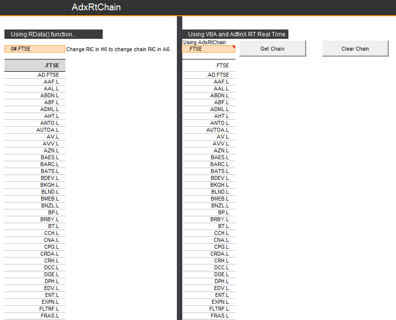

### VBA

In VBA, we went through with the creation of `cmdGetChain_Click`:

> ```
> Private Sub cmdGetChain_Click()
>     ActiveCell.Select
>
>     If myAdxRtChain Is Nothing Then Set myAdxRtChain = CreateAdxRtChain()
>
>     With myAdxRtChain
>         .Source = "IDN"
>         .ItemName = Range("G6").Value
>         .RequestChain
>     End With
> End Sub
> ```

then `myAdxRtChain_OnUpdate`:

> ```
> Private Sub myAdxRtChain_OnUpdate(ByVal DataStatus As AdfinXRtLib.RT_DataStatus)
>     Dim i As Integer
>
>     If DataStatus = RT_DS_FULL Then
>         For i = 1 To UBound(myAdxRtChain.Data)
>             Range("G8").Offset(i - 1, 0).Value = myAdxRtChain.Data(i)
>         Next i
>     End If
> End Sub
> ```

then we ought to make sure we can close the connection with `cmdClearChain_Click`, which is done simply in Python with `rd.close_session()`.

We can replicate this easily in Python with the Pricing snapshots and Fundamental & Reference data function `get_data()` - moreover we can decode the chain and request fields in one operation:

### Python

```python
FTSEConstituentDf1 = rd.get_data(
    universe=['0#.FTSE'],
    fields=['TR.TURNOVER.timestamp', 'TR.TURNOVER', 'TR.EVToSales'])
FTSEConstituentDf1
```

|  | Instrument | Timestamp | Turnover | Enterprise Value To Sales (Daily Time Series Ratio) |
| --- | --- | --- | --- | --- |
| 0 | STAN.L | 2023-03-06T00:00:00Z | 5254690524.0795 | 3.641311 |
| 1 | CRDA.L | 2023-03-06T00:00:00Z | 1274351304.23038 | 4.528984 |
| 2 | ANTO.L | 2023-03-06T00:00:00Z | 2642480584.4064 | 3.978246 |
| 3 | BNZL.L | 2023-03-06T00:00:00Z | 1357517624.49449 | 0.956368 |
| 4 | SGE.L | 2023-03-06T00:00:00Z | 1904311639.98092 | 4.387063 |
| ... | ... | ... | ... | ... |
| 95 | EDV.L | 2023-03-06T00:00:00Z | 298534187.4035 | 2.206513 |
| 96 | OCDO.L | 2023-03-06T00:00:00Z | 1123284787.22775 | 2.010882 |
| 97 | LSEG.L | 2023-03-06T00:00:00Z | 2993876995.24628 | 6.336949 |
| 98 | TSCO.L | 2023-03-06T00:00:00Z | 3041956489.34064 | 0.468989 |
| 99 | LGEN.L | 2023-03-06T00:00:00Z | 2561324328.19983 | <NA> |

100 rows × 4 columns

#### Not all chains resolve directly - for example a commodity chain - in such cases we can use the Chain Object to decode as follows:

```python
LCOConstituentDf = rd.get_data(
    universe=Chain('0#LCO:'),
    fields=["CF_NAME", "CF_CLOSE", "OPINT_1"])

LCOConstituentDf
```

|  | Instrument | CF_NAME | CF_CLOSE | OPINT_1 |
| --- | --- | --- | --- | --- |
| 0 | LCOTOT | BRENT CRUDE VOLS | <NA> | 2459512 |
| 1 | LCOK3 | BRENT CRUDE MAY3 | 86.18 | 467381 |
| 2 | LCOM3 | BRENT CRUDE JUN3 | 85.62 | 448239 |
| 3 | LCON3 | BRENT CRUDE JUL3 | 85.16 | 182689 |
| 4 | LCOQ3 | BRENT CRUDE AUG3 | 84.69 | 111730 |
| ... | ... | ... | ... | ... |
| 79 | LCOX9 | BRENT CRUDE NOV9 | 65.08 | <NA> |
| 80 | LCOZ9 | BRENT CRUDE DEC9 | 65.06 | <NA> |
| 81 | LCOF0 | BRENT CRUDE JAN0 | 65.04 | <NA> |
| 82 | LCOG0 | BRENT CRUDE FEB0 | 65.02 | <NA> |
| 83 | LCOH0 | BRENT CRUDE MAR0 | 65.0 | <NA> |

84 rows × 4 columns

## AdfinX RealTime - AdxRtHistory - Interday Time Series History

### What does AdxRtHistory do?

Adfin RealTime History (AdxRtHistory) is used to retrieve interday (not intraday) time series (historic) data for an instrument or instruments. This was best exemplified in [Tutorial 5 - Time Series History - AdxRtHistory](https://developers.refinitiv.com/en/api-catalog/eikon/com-apis-for-use-in-microsoft-office/tutorials#tutorial-5-time-series-history-adx-rt-history)'s [Excel Workbook](https://developers.refinitiv.com/content/dam/devportal/api-families/eikon/com-apis-for-use-in-microsoft-office/tutorials/adxrthistory.zip):

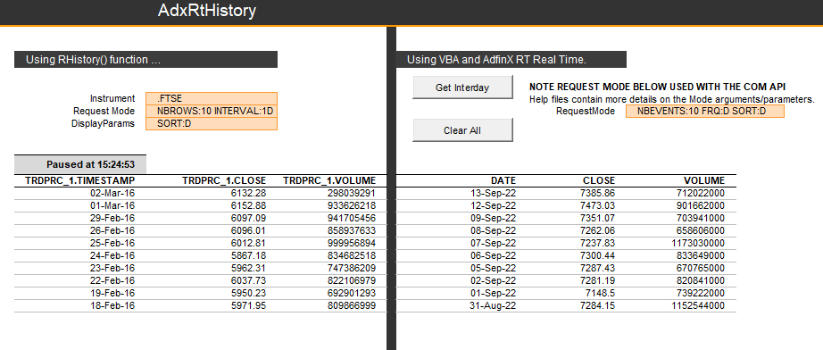

### VBA

In VBA, we used `AdfinXRtLib`:

> ```
> ' Note the use of CreateReutersObject - function in the PLVbaApis module.
>     If myAdxRtHist Is Nothing Then Set myAdxRtHist = CreateReutersObject("AdfinXRtLib.AdxRtHistory")
>
>     On Error GoTo errHndlr
>     With myAdxRtHist
>         .FlushData
>         .ErrorMode = EXCEPTION ' EXCEPTION, DialogBox, NO_EXCEPTION
>         .Source = "IDN"
>         .ItemName = [C7].Value
>         .Mode = [H8].Value
>         .RequestHistory ("DATE,CLOSE,VOLUME") 'NOTE USE OF OLD FIELD NAMES, NOT ("TRDPRC_1.TIMESTAMP,TRDPRC_1.CLOSE,TRDPRC_1.VOLUME")
>
>         'arrFlds = Array("DATE","CLOSE","VOLUME")
>         '.RequestHistory ()arrFlds
>         '.RequestHistory ("*") ' "*" requests all fields.
>     End With
> ```

before the `Private Sub` '`myAdxRtHist_OnUpdate(ByVal DataStatus As AdfinXRtLib.RT_DataStatus)`'.

Things are simpler in Python:

### Python

As aforementioned, AdxRtHistory is used to retrieve time series (historic) data for an instrument or instruments except for intraday data. This is exactly what the instruments `get_history` is for!

```python
FTSEConstituents = list(FTSEConstituentDf1['Instrument'])
print(FTSEConstituents)
```

```
['STAN.L', 'CRDA.L', 'ANTO.L', 'BNZL.L', 'SGE.L', 'SVT.L', 'BLND.L', 'ICAG.L', 'REL.L', 'SMIN.L', 'AZN.L', 'HSBA.L', 'CTEC.L', 'WPP.L', 'FRES.L', 'AAF.L', 'SGRO.L', 'SJP.L', 'TW.L', 'AHT.L', 'HLMA.L', 'III.L', 'CNA.L', 'MNG.L', 'BKGH.L', 'SMDS.L', 'NG.L', 'RKT.L', 'SKG.L', 'WEIR.L', 'MRON.L', 'HSX.L…
```

```python
FTSEConstituents[0:6]
```

```
['STAN.L', 'CRDA.L', 'ANTO.L', 'BNZL.L', 'SGE.L', 'SVT.L']
```

```python
TimeSeriesDf = rd.get_history(
    universe=FTSEConstituents[1:6],
    fields=['TR.PriceClose', 'TR.Volume'],  # 'TR' fields are usually historic ones.
    interval="1D",
    start="2022-01-25",
    end="2022-02-01")

TimeSeriesDf
```

| Date | CRDA.L Price Close | CRDA.L Volume | ANTO.L Price Close | ANTO.L Volume | BNZL.L Price Close | BNZL.L Volume | SGE.L Price Close | SGE.L Volume | SVT.L Price Close | SVT.L Volume |
| --- | --- | --- | --- | --- | --- | --- | --- | --- | --- | --- |
| 2022-01-25 | 7666 | 371438 | 1379.0 | 1429044 | 2721 | 678948 | 762.4 | 3467017 | 2858 | 642275 |
| 2022-01-26 | 7830 | 755599 | 1411.5 | 889172 | 2754 | 628530 | 713.0 | 4323758 | 2871 | 318280 |
| 2022-01-27 | 7880 | 754142 | 1391.5 | 1460311 | 2776 | 671478 | 701.0 | 4752740 | 2914 | 522647 |
| 2022-01-28 | 7774 | 510683 | 1337.5 | 2839242 | 2786 | 1203491 | 711.2 | 3683775 | 2893 | 1017099 |
| 2022-01-31 | 7972 | 442252 | 1332.5 | 1333271 | 2767 | 545449 | 720.8 | 2966860 | 2873 | 751851 |
| 2022-02-01 | 8008 | 690445 | 1361.5 | 1605104 | 2775 | 433783 | 718.6 | 4462156 | 2903 | 439666 |

## AdxRtHistory - Intraday Time Series History

### VBA

Adfin RealTime History (AdxRtHistory) Intraday is similar

Which had few VBA lines needed:

> ```
> Private Sub cmdGetInterday_Click()
>     ActiveCell.Select
>
>     MsgBox "AdxRtHistory cannot retrieve INTRA day data, use the RHistoryAPI instead"
> End Sub
> ```

### Python

Intraday data is just as easy to get:

```python
IntradayTimeSeriesDf = rd.get_history(
    universe=FTSEConstituents,
    fields=['TRDPRC_1'],
    interval="1min",  # The consolidation interval. Supported intervals are: tick, tas, taq, minute, 1min, 5min, 10min, 30min, 60min, hourly, 1h, daily, 1d, 1D, 7D, 7d, weekly, 1W, monthly, 1M, quarterly, 3M, 6M, yearly, 1Y.
    start="2022-06-01T13:00:00",
    end="2022-06-01T15:30:00")

IntradayTimeSeriesDf
```

| TRDPRC_1 Timestamp | STAN.L | CRDA.L | ANTO.L | BNZL.L | SGE.L | SVT.L | BLND.L | ICAG.L | REL.L | SMIN.L | AZN.L | HSBA.L | CTEC.L | WPP.L | FRES.L | AAF.L | SGRO.L | SJP.L | TW.L | AHT.L | HLMA.L | III.L | CNA.L | MNG.L | BKGH.L | SMDS.L | NG.L | RKT.L | SKG.L | … |
| --- | --- | --- | --- | --- | --- | --- | --- | --- | --- | --- | --- | --- | --- | --- | --- | --- | --- | --- | --- | --- | --- | --- | --- | --- | --- | --- | --- | --- | --- | --- |
| 2022-06-01 13:00:00 | 636.8 | <NA> | <NA> | 2785.0 | 652.2 | 2855.0 | 526.506 | 129.2256 | <NA> | 1570.0 | 10492.0 | 535.4 | <NA> | 937.2 | <NA> | <NA> | 1096.0 | 1256.5 | 130.95 | 4115.0 | 2198.0 | <NA> | 80.0871 | <NA> | 4253.0 | 306.7 | 1127.4703 | <NA> | 3221.0 | … |
| 2022-06-01 13:01:00 | 636.8 | 6884.0 | <NA> | 2784.0 | <NA> | 2854.0 | 526.6 | 128.74 | 2242.0 | <NA> | 10492.0 | 535.5 | 217.8 | 937.4 | <NA> | <NA> | <NA> | <NA> | 130.9 | 4114.0 | <NA> | 1251.5725 | 80.14 | <NA> | 4256.0 | 306.768 | 1127.35 | <NA> | 3223.0 | … |
| 2022-06-01 13:02:00 | 636.6 | 6882.0 | 1507.0 | <NA> | <NA> | <NA> | 526.4 | 128.64 | 2242.0 | 1570.78 | 10494.0 | 535.2998 | <NA> | 937.0804 | <NA> | <NA> | <NA> | 1258.0 | 131.0 | <NA> | 2202.0 | <NA> | 80.12 | 218.05 | 4258.0 | <NA> | 1128.0 | <NA> | <NA> | … |
| 2022-06-01 13:03:00 | <NA> | 6890.0 | <NA> | 2787.0 | 652.6 | 2854.0 | 526.8 | 128.68 | 2243.0 | 1570.5 | 10494.0 | 535.3982 | 218.0 | 937.8 | <NA> | <NA> | <NA> | <NA> | 131.05 | 4121.0 | 2209.0 | 1252.2297 | 80.12 | <NA> | <NA> | <NA> | <NA> | 6252.0 | 3226.0 | … |
| 2022-06-01 13:04:00 | 636.4 | 6892.0 | 1509.0 | 2785.0 | 653.0 | 2853.0 | <NA> | 128.74 | 2244.0 | 1572.0 | 10495.7 | 535.3 | <NA> | <NA> | 770.2 | <NA> | <NA> | 1259.5 | <NA> | 4124.0 | 2210.0 | 1252.0 | 80.1 | <NA> | 4258.0 | 306.5 | 1128.3498 | 6248.0 | 3228.0 | … |
| ... | ... | ... | ... | ... | ... | ... | ... | ... | ... | ... | ... | ... | ... | ... | ... | ... | ... | ... | ... | ... | ... | ... | ... | ... | ... | ... | ... | ... | ... | … |
| 2022-06-01 15:25:00 | 632.4 | 6782.0 | 1499.5 | 2787.0 | 652.0 | 2837.0 | 521.2 | 126.54 | 2207.0 | 1557.5 | 10432.0 | 528.6 | 214.0 | 923.4 | 770.8 | 154.4 | 1085.0 | 1243.0 | 129.7 | 4026.0 | 2187.0 | 1242.5 | 80.0 | 216.4 | 4241.0 | 302.5 | 1118.8497 | 6162.0 | 3178.0 | … |
| 2022-06-01 15:26:00 | 632.4 | 6778.0 | 1498.5 | 2787.0 | 652.4 | 2836.6495 | 521.0 | 126.68 | 2207.0 | 1557.5 | 10432.0 | 528.5829 | 213.8 | 924.0 | <NA> | 154.4 | 1083.5 | 1242.5 | 129.65 | 4024.0 | 2187.0 | 1243.0 | 79.94 | 216.2096 | 4240.0 | 302.8 | 1118.5 | 6164.0 | 3179.0 | … |
| 2022-06-01 15:27:00 | 632.4 | 6778.0 | <NA> | 2790.0 | 652.6 | 2838.0 | 520.8 | 126.64 | 2208.0 | 1558.0 | 10436.0 | 528.8 | 214.0 | 923.8 | 769.8 | 154.3 | 1083.5 | 1243.0 | 129.6 | 4026.0 | 2189.0 | 1242.5 | 79.92 | <NA> | 4237.0 | 302.6321 | 1119.0 | 6166.0 | 3179.0 | … |
| 2022-06-01 15:28:00 | 632.4 | 6780.0 | 1499.0 | 2788.0 | 652.8 | 2836.0 | 521.2 | 126.64 | 2207.0 | 1558.5 | 10428.0 | 528.7 | 213.8 | 923.8 | <NA> | 154.2 | 1084.5 | 1242.5 | 129.65 | 4029.0 | 2190.0 | 1241.0 | 79.92 | 216.3931 | 4238.0 | 302.8 | 1119.0 | 6168.0 | 3184.0 | … |
| 2022-06-01 15:29:00 | 632.4 | 6782.0 | 1500.0 | 2793.0 | 652.4 | 2836.0 | 520.6 | 126.54 | 2206.0 | 1558.5 | 10424.0 | 528.4 | 214.0 | 923.8 | 768.4 | 154.0 | 1084.0 | 1242.0 | 129.65 | 4027.0 | 2188.0 | 1241.0 | 80.02 | 216.2 | 4238.0 | 302.3 | 1118.0 | 6172.0 | 3186.0 | … |

150 rows × 100 columns

As you can see, we get the data sought after. If you are after several fields for any one instrument (e.g.: an FX Pair), it couldn't be any simpler.

## DEX2.dll

The DEX2.dll COM API component provides access to a broad range of fundamental and reference data (including all the TR.xxx fields). The RData Excel function provided both Fundamental and Reference as well as streaming realtime prices and news using this component under the hood along with RTX.dll.

### Rdata List Realtime

When using the old COM API to get `Rdata List` data, one may be greeted with an Excel sheet that looks like this:

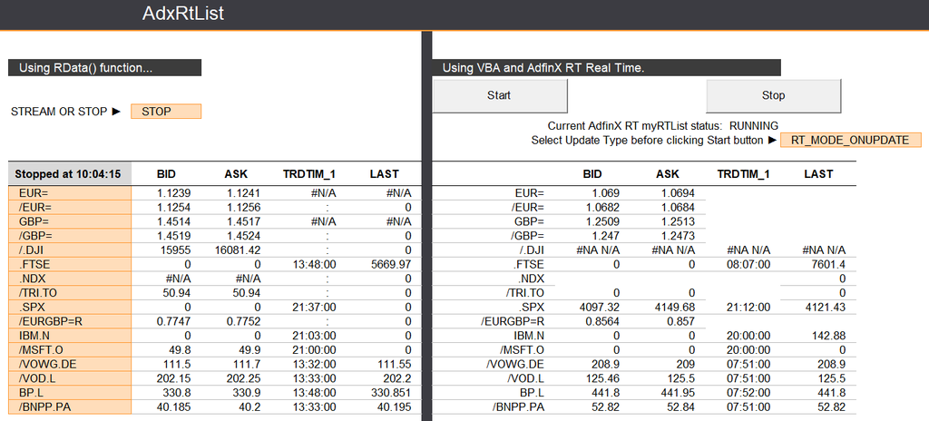

#### VBA

In VBA, this was done with a function akin to `.StartUpdates RT_MODE_ONUPDATE` & `myRTList = CreateAdxRtList()`, e.g.:

> ```
> With myRTList
>     .ErrorMode = EXCEPTION
>     ' N.B.! Source name may need to be changed if not named as below!
>     .Source = "IDN" '_SELECTFEED"
>     ' Register the items and fields
>     .RegisterItems ItemArray, FieldArray
>
>     ' Set the user tag on each item. This helps indexing the results
>     ' table for displaying the data in the callback
>     For m = LBound(ItemArray) To UBound(ItemArray)
>         .UserTag(ItemArray(m), "*") = m
>         For n = LBound(FieldArray) To UBound(FieldArray)
>             .UserTag(ItemArray(m), FieldArray(n)) = n
>         Next n
>     Next m
>
>     .Mode = "TIMEOUT:5"
>     ' If timed basis desired, then FRQ setting and RT_MODE_ONTIME or RT_MODE_ONTIME_IF_UPDATED required,
>     ' which will trigger the OnUpdate event, shown below.
>     '.Mode = "FRQ:2S"
>     ' And, finally, request the data!
>     Select Case Range("dcUpdateType").Value
>         Case "RT_MODE_IMAGE"
>             .StartUpdates RT_MODE_IMAGE
>         Case "RT_MODE_ONUPDATE"
>             .StartUpdates RT_MODE_ONUPDATE
>     End Select
>
>     '.StartUpdates RT_MODE_ONUPDATE
>     '.StartUpdates RT_MODE_IMAGE
>     'Other modes shown below; different events will be fired.
>     '.StartUpdates RT_MODE_ONTIME, RT_MODE_ONTIME_IF_UPDATED, RT_MODE_ONTIME,
>     ' RT_MODE_ONUPDATE, RT_MODE_IMAGE , RT_MODE_NOT_SET
> End With
> ```

To stop this update, you would have to create some VBA code to (e.g.: `Sub cmdStop_Click()`), but that is simpler in Python with `stream.close()`:

However - many developers also used the RData worksheet function object directly in VBA.

#### Python

Here we have a data-frame of instruments and fields updating live every `x` seconds, let's say (for the sake of the use-case example) every 3 seconds. This is simple to recreate in Python:

```python
#define stream
stream = rd.open_pricing_stream(
    universe=['GBP=', 'EUR=', 'JPY=', '.GDAXI', '.FTSE', '.NDX', 'TRI.TO', 'EURGBP=R'],
    fields=['CF_TIME', 'CF_LAST', 'BID', 'ASK', 'TRDTIM_1'])
```

```python
#open stream
stream.open()
```

```
<OpenState.Opened: 'Opened'>
```

```python
#add temporal update functionality using stream.get_snapshot
now = time.perf_counter()
while time.perf_counter() < now + 30:
    time.sleep(3)
    clear_output(wait=True)
    df = stream.get_snapshot(
        universe=['GBP=', 'EUR=', 'JPY=', '.GDAXI', '.FTSE', '.NDX', 'TRI.TO', 'EURGBP=R'],
        fields=['CF_TIME', 'CF_LAST', 'BID', 'ASK', 'TRDTIM_1'])
    display(df)
```

|  | Instrument | CF_TIME | CF_LAST | BID | ASK | TRDTIM_1 |
| --- | --- | --- | --- | --- | --- | --- |
| 0 | GBP= | 11:44:36 | 1.1983 | 1.1983 | 1.1987 | <NA> |
| 1 | EUR= | 11:44:36 | 1.0657 | 1.0657 | 1.0661 | <NA> |
| 2 | JPY= | 11:44:37 | 136.02 | 136.02 | 136.03 | <NA> |
| 3 | .GDAXI | 11:44:00 | 15677.13 | <NA> | <NA> | 11:44:00 |
| 4 | .FTSE | 11:44:00 | 7948.93 | <NA> | <NA> | 11:44:00 |
| 5 | .NDX | 22:15:59 | 12302.484 | <NA> | <NA> | <NA> |
| 6 | TRI.TO | 21:00:00 | 165.81 | 162.61 | 167 | <NA> |
| 7 | EURGBP=R | 11:44:37 | 0.889 | 0.889 | 0.8897 | <NA> |

Close the stream

```python
stream.close()
```

```
<OpenState.Closed: 'Closed'>
```

#### Create a Streaming Price and register event callbacks using RDP

You can build upon the example above, using the [RDP](https://developers.refinitiv.com/en/api-catalog/refinitiv-data-platform/refinitiv-data-platform-apis) Example notebook present in Codebook that demonstrates how to use a StreamingPrice with events to update a Pandas DataFrame with real-time streaming data. Using a StreamingPrices object that way allows your application to have at its own in memory representation (a Pandas DataFrame in this example) that is kept updated with the latest streaming values received from Eikon or Refinitiv Workspace. Here we're putting ourselves in the shoes of a Foreign eXchange (FX) trader looking at Emerging Market (EM) currency exchange rates; e.g: the Nigerian Nairas (NGN) and Indonesian Rupiah (IDR).

You can find the code for this on GitHub [here](https://gist.github.com/johnukfr/25935ae4a0928c400e706dee7eb6a79a).